# R Notebook

**MGMT 3345 Unit 1 Project**

**STEP 1** #Complete this step in Excel.

Real returns were calculated in Excel using the CPI-deflation method:

```
Real Return (%) = ( (P_t / P_t-1) / (CPI_t / CPI_t-1) - 1 ) * 100
```

Per the project instructions, the CPI for October 2025 was set to the Treasury Department’s contingency index of 325.604 (BLS did not release an official October 2025 CPI due to the government shutdown). See the “Source Data” tab of `Fidelity_Real_Returns.xlsx` for the priced/CPI inputs and the “Fidelity” tab for the resulting 58 real-return observations (Feb 2021 - Nov 2025).

Import the completed real returns file for use in the remaining steps.

```r
# Update this path if your file lives somewhere else on your machine.
df <- read_excel("data/Fidelity_Real_Returns.xlsx", sheet = "Fidelity")

# Row 1 (Jan 2021) has no prior month price, so it has no real return.
# Drop it, leaving the 58 monthly real-return observations (Feb 2021-Nov 2025).
df <- df[-1, ]

str(df)
```

```
tibble [58 x 7] (S3: tbl_df/tbl/data.frame)
 $ Date                  : POSIXct[1:58], format: "2021-02-01" "2021-03-01" ...
 $ Consumer_Staples      : num [1:58] 7.99 -3.22 10.28 -1.44 1.05 ...
 $ Energy                : num [1:58] 0.582 -0.666 6.761 3.847 -9.186 ...
 $ Financials            : num [1:58] 6.067 5.516 2.644 -4.751 -0.879 ...
 $ Health_Care           : num [1:58] -0.3 0.96 4.494 2.227 0.352 ...
 $ Information_Technology: num [1:58] -0.768 -3.35 9.612 6.135 1.387 ...
 $ Utilities             : num [1:58] 8.14 3.04 -4.14 -1.6 1.73 ...
```

**STEP 2** #Descriptive statistics

```r
funds <- c("Consumer_Staples", "Energy", "Financials",
           "Health_Care", "Information_Technology", "Utilities")

fund_mean <- sapply(df[funds], mean)
fund_sd   <- sapply(df[funds], sd)

descriptive_stats <- data.frame(
  Fund               = funds,
  `Monthly Return (Mean)` = round(fund_mean, 4),
  `Standard Deviation`    = round(fund_sd, 4),
  check.names = FALSE
)

descriptive_stats
```

|  | Fund | Monthly Return (Mean) | Standard Deviation |
| --- | --- | --- | --- |
| Consumer_Staples | Consumer_Staples | 0.5021 | 4.7209 |
| Energy | Energy | 1.3632 | 7.2890 |
| Financials | Financials | 1.2556 | 7.0954 |
| Health_Care | Health_Care | 0.4112 | 5.5297 |
| Information_Technology | Information_Technology | 1.6394 | 7.4317 |
| Utilities | Utilities | 1.0573 | 5.3919 |

Copy these mean and standard deviation values (rounded to 4 decimal places) into the Step 2a table in the Word document.

**STEP 3** #Graphs

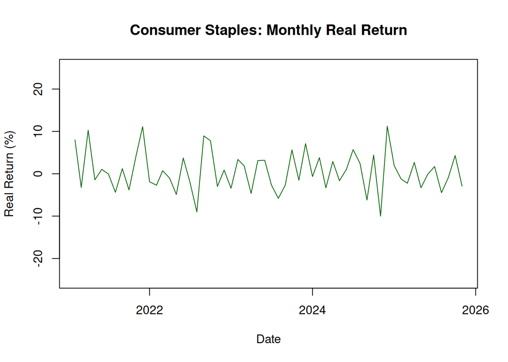

```r
plot(df$Consumer_Staples ~ df$Date, main = "Consumer Staples: Monthly Real Return",
     xlab = "Date", ylab = "Real Return (%)", col = "darkgreen", type = "l",
     ylim = c(-25, 25))
```

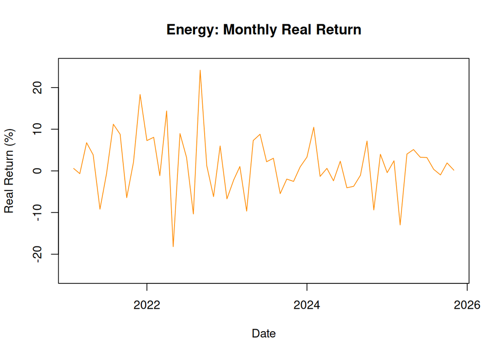

```r
plot(df$Energy ~ df$Date, main = "Energy: Monthly Real Return",
     xlab = "Date", ylab = "Real Return (%)", col = "darkorange", type = "l",
     ylim = c(-25, 25))
```

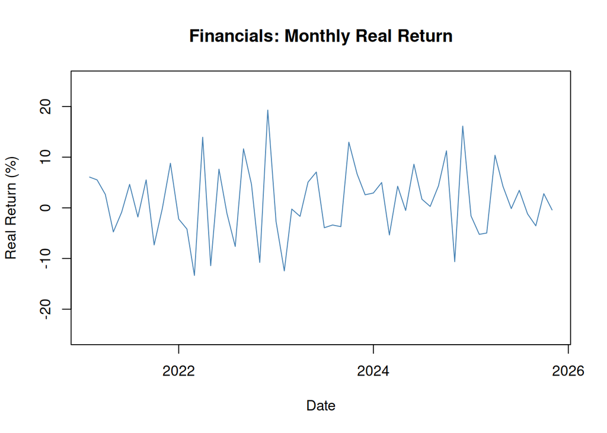

```r
plot(df$Financials ~ df$Date, main = "Financials: Monthly Real Return",
     xlab = "Date", ylab = "Real Return (%)", col = "steelblue", type = "l",
     ylim = c(-25, 25))
```

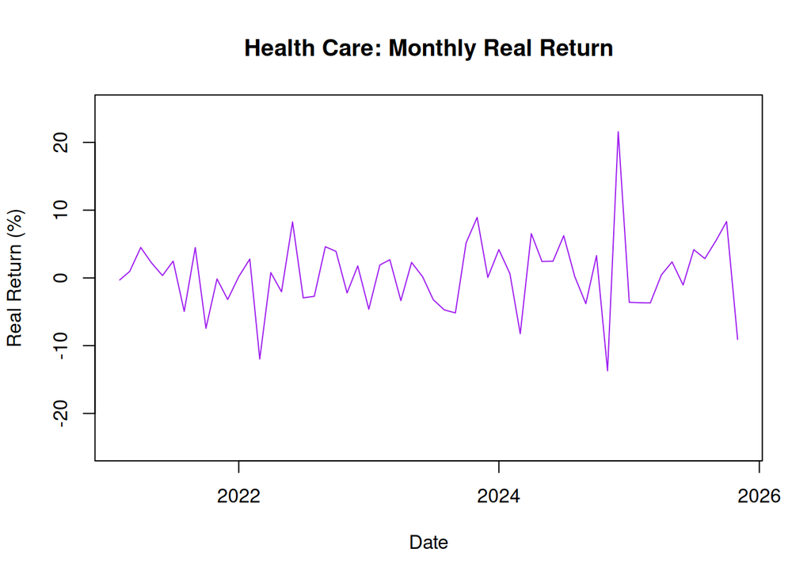

```r
plot(df$Health_Care ~ df$Date, main = "Health Care: Monthly Real Return",
     xlab = "Date", ylab = "Real Return (%)", col = "purple", type = "l",
     ylim = c(-25, 25))
```

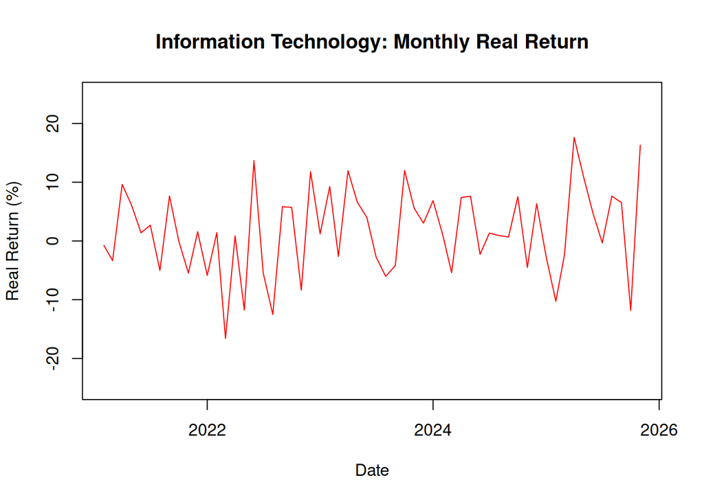

```r
plot(df$Information_Technology ~ df$Date, main = "Information Technology: Monthly Real Return",
     xlab = "Date", ylab = "Real Return (%)", col = "red", type = "l",
     ylim = c(-25, 25))
```

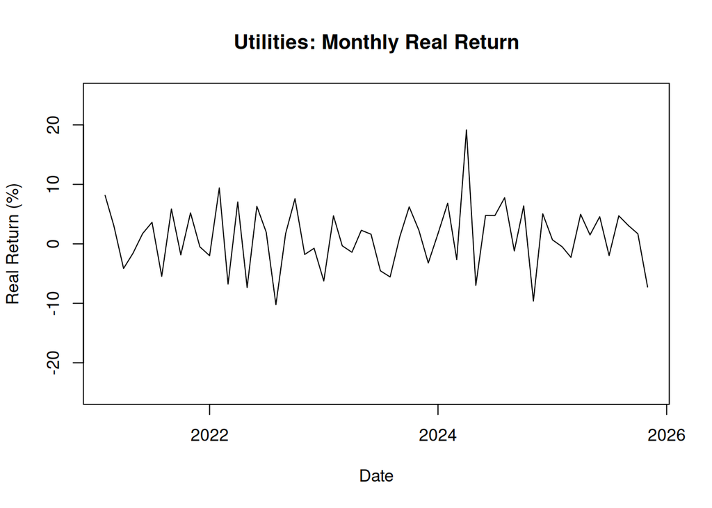

```r
plot(df$Utilities ~ df$Date, main = "Utilities: Monthly Real Return",
     xlab = "Date", ylab = "Real Return (%)", col = "black", type = "l",
     ylim = c(-25, 25))
```

**Step 3b. What can you say about the returns for each company?**

**STEP 4** #Portfolios

Each portfolio invests 40% in the first fund listed and 60% in the second fund listed.

```r
portfolio <- function(x, y, w1 = 0.4, w2 = 0.6) {
  rho <- cor(x, y)
  exp_return <- w1 * mean(x) + w2 * mean(y)
  variance <- (w1^2) * var(x) + (w2^2) * var(y) + 2 * w1 * w2 * cov(x, y)
  std_dev <- sqrt(variance)

  round(c(
    Correlation      = rho,
    `Expected Return` = exp_return,
    Variance         = variance,
    `Standard Deviation` = std_dev
  ), 4)
}
```

```r
# Portfolio 1: Health_Care (40%) / Information_Technology (60%)
portfolio(df$Health_Care, df$Information_Technology)
```

```
       Correlation    Expected Return           Variance Standard Deviation
            0.4119             1.1481            32.9008             5.7359
```

```r
# Portfolio 2: Energy (40%) / Utilities (60%)
portfolio(df$Energy, df$Utilities)
```

```
       Correlation    Expected Return           Variance Standard Deviation
            0.3199             1.1797            25.0023             5.0002
```

```r
# Portfolio 3: Consumer_Staples (40%) / Financials (60%)
portfolio(df$Consumer_Staples, df$Financials)
```

```
       Correlation    Expected Return           Variance Standard Deviation
            0.5605             0.9542            30.7020             5.5409
```

Copy each portfolio’s correlation coefficient, expected return, variance, and standard deviation (rounded to 4 decimal places) into the Step 4 tables in the Word document, and state which two funds you chose for each one.

**STEP 5** #Analysis (complete in the Word document)